The last step to do is to check that we can actually load and run our library from github in R. To do that, we can run the following code:

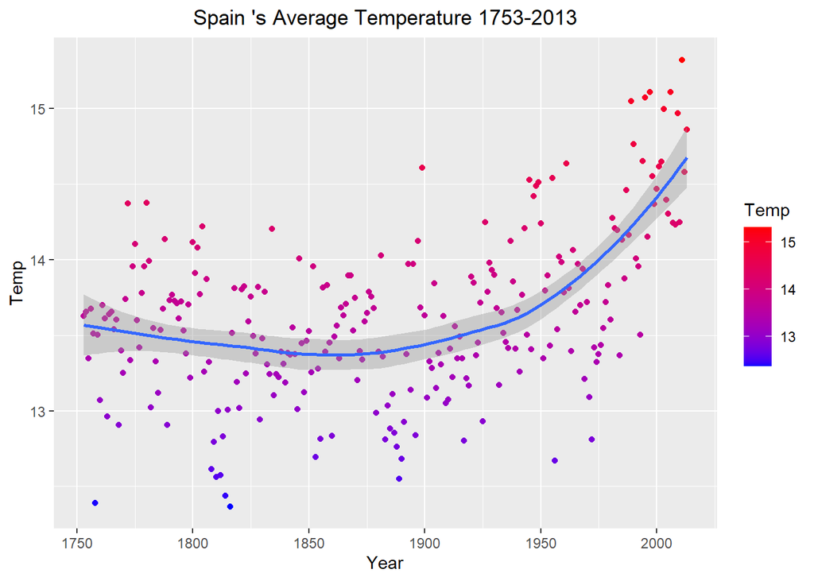

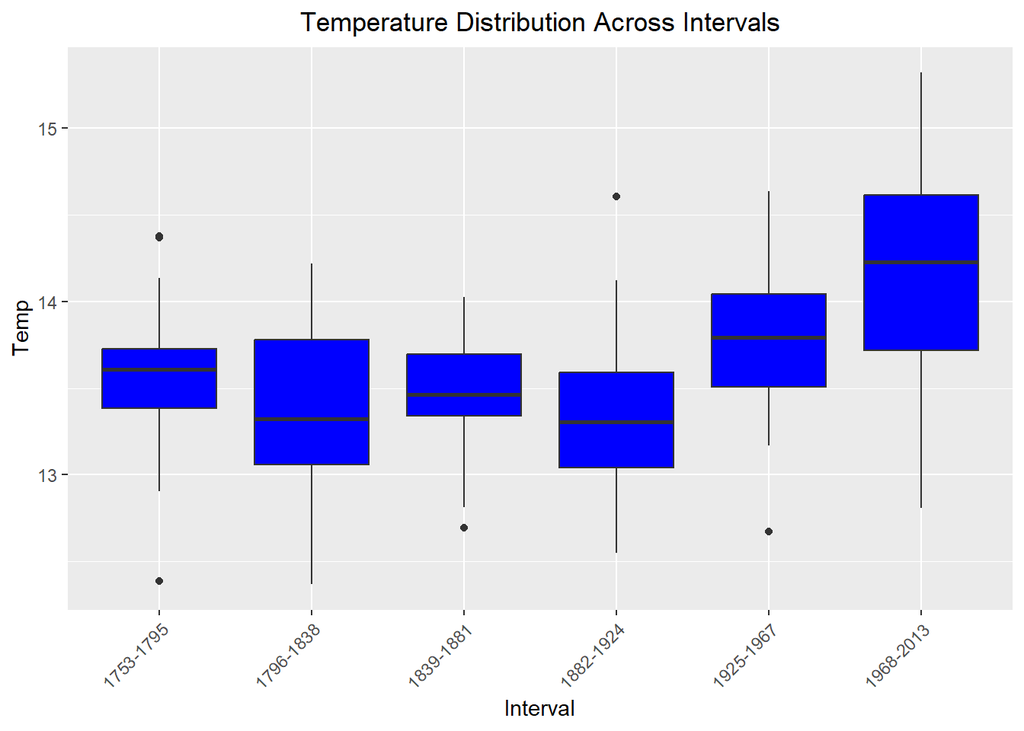

```
##              Df Sum Sq Mean Sq F value Pr(>F)
## Interval      5  23.31   4.662   22.64 <2e-16 ***
## Residuals   255  52.49   0.206
## ---
## Signif. codes:  0 '***' 0.001 '**' 0.01 '*' 0.05 '.' 0.1 ' ' 1
## Tables of means
## Grand mean
##
## 13.62374
##
##  Interval
##     1753-1795 1796-1838 1839-1881 1882-1924 1925-1967 1968-2013
##          13.6      13.4      13.5      13.3      13.8      14.2
## rep      44.0      43.0      43.0      43.0      43.0      45.0
##
##  Shapiro-Wilk normality test
##
## data:  residuals(anova_result)
## W = 0.99517, p-value = 0.5874
##
## Levene's Test for Homogeneity of Variance (center = median)
##        Df F value    Pr(>F)
## group   5  4.4917 0.0006103 ***
##       255
## ---
## Signif. codes:  0 '***' 0.001 '**' 0.01 '*' 0.05 '.' 0.1 ' ' 1
## [1] "ANOVA assumptions violated. Proceeding with Welch's ANOVA and Games-Howell test."
##
##  One-way analysis of means (not assuming equal variances)
##
## data:  Temp and Interval
## F = 16.443, num df = 5.00, denom df = 118.44, p-value = 2.656e-12
##
##           1753-1795 1796-1838 1839-1881 1882-1924 1925-1967
## 1796-1838 0.29434   -         -         -         -
## 1839-1881 0.85592   0.81447   -         -         -
## 1882-1924 0.07797   0.99769   0.42883   -         -
## 1925-1967 0.04155   0.00016   0.00068   7.9e-06   -
## 1968-2013 4.7e-06   1.6e-08   7.6e-08   1.1e-09   0.02639
```

```r
devtools::install_github("MidnightRequiem/clinsis")
library(clinsis)
analyzeTemperatureData("Spain")
```

**As you can see, the library works flawlessly.**

Annex

**Interpreting the output of the perform_diagnostics() function in SARIMA forecast**

Interpreting the output graphs and tests from a Seasonal Autoregressive Integrated Moving Average (SARIMA) model in R involves understanding the diagnostics for time series analysis. Here’s a very basic guide to interpreting these key elements:

* Standardized Residuals: This graph shows the residuals (errors) of the model divided by their estimated standard deviation. Ideally, these residuals should look like white noise, meaning they are normally distributed with a mean of zero and constant variance. Large deviations from zero suggest model inadequacies.

* ACF of Residuals: The Autocorrelation Function (ACF) plot for the residuals shows the correlation of the series with its own lagged values. In a well-fitting model, the ACF should show no significant autocorrelation. If significant autocorrelation is present (indicated by bars exceeding the significance bounds), the model might need further tuning.

* p-Values for Ljung-Box Test: The Ljung-Box test checks the overall randomness based on a number of lags. The p-values indicate whether the residuals have significant autocorrelations at different lag lengths. Higher p-values (typically above 0.05) suggest that the residuals are independent at the 95% confidence level, indicating a good model fit.

* Residuals of Dataset: This is a plot of residuals over time. We want to check for any patterns or systematic structures. Ideally, residuals should appear as a random cloud of points centered around zero without any discernible pattern. Patterns or trends may indicate that the model has not fully captured the underlying process.

* ACF of Dataset Residuals: Similar to the ACF of residuals, but focused specifically on the residuals of the dataset. We are looking for the absence of significant correlations here as well.

* PACF of Dataset Residuals: The Partial Autocorrelation Function (PACF) shows the correlation of the residuals with its own lagged values, controlling for the values of the time series at all shorter lags. Significant spikes in the PACF plot (beyond the significance bounds) may suggest that additional lags should be included in the model.

* Shapiro-Wilk Test: This test is used to assess the normality of the residuals. If the residuals are normally distributed, it supports the assumption that the errors are normally distributed - a key assumption in many time series models. A high p-value (typically >0.05) indicates that the residuals are normally distributed.

In summary, when analyzing SARIMA model outputs, we are essentially checking whether the residuals resemble white noise (no autocorrelation, normally distributed, mean around zero, constant variance), and whether the model has adequately captured the patterns in the data without overfitting or underfitting. If the diagnostics suggest otherwise, we may need to revisit the model choice, including the parameters for the autoregressive (AR), differencing (I), and moving average (MA) components, as well as the seasonal components of the SARIMA model.